# segRDA: An R package for performing piecewise redundancy analysis

Danilo Cândido Vieira; Marco Colossi Brustolin; Fabio Cop; Gustavo Fonseca.

June 22, 2018

The `segRDA` requires the `vegan` package (Oksanen et al. 2017). `segRDA`compiles three functions: (1) data ordering, (2) breakpoints detection and (3) piecewise redundancy analysis.

The code below demonstrates how to use the `segRDA` package. Throughout this document we will use the dataset `sim2` from the package, which is composed by two matrices: `envi` and `comm`.

```r
data(sim2) ##Simulated data
x<-sim2$envi ## matrix of explanatory variables
y<-sim2$comm ## matrix of response variables
```

A transformation of y is recommended to ensure the homoscedasticity of the response variables. One option is to use the function decostand from `vegan`.

```r
y<-decostand(y,"hell")
```

# 1 Data ordering

Both SMW and pwRDA analysis depend on ordered datasets. The ordering can be user-defined or generated using `OrdData` function. The latter orders both response and explanatory matrices using the first axis of a full RDA model.

```r
sim.ord<-OrdData(x=x,y=y)
x.ord<-sim.ord$x
y.ord<-sim.ord$y
```

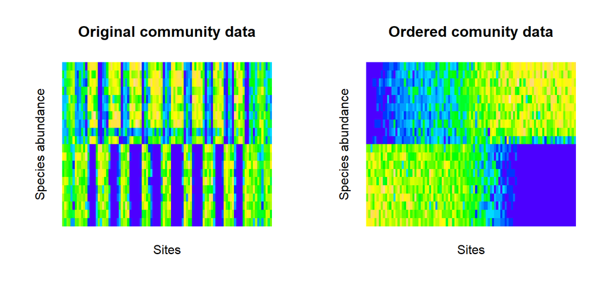

```r
par(mfrow=c(1,2), mgp=c(1,1,0))
image(y, main="Original community data", col=topo.colors(100), axes=F, xlab="Sites", ylab="Species abundance")
image(y.ord, main="Ordered comunity data", col=topo.colors(100), axes=F, xlab="Sites", ylab="Species abundance")
```